# Analysis of longitudal data / week 6

## Data analysis of RATS data

We will first analyze data from a nutrition study conducted in three groups of rats (Crowder and Hand, 1990). Groups had different diets and the body weights of each individual was recorded for 9 weeks. We are studying whether the diets had an effect on the growth profiles.

### Individual growth profiles by diet group for the RATS data.

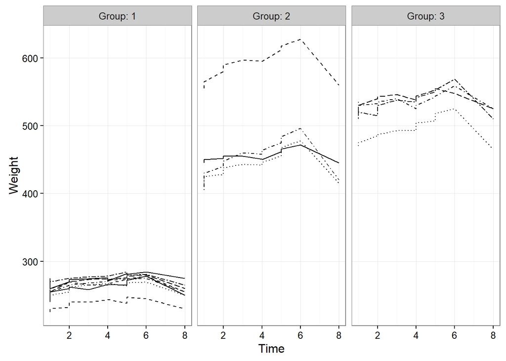

From the above graphs we can see that the profiles look quite similar across the different diets. The weight increases until week 6 and then starts to drop towards the original value. Rats in groups 2 and 3 have higher weights overall compared to group 1. In group 2 there is one individual that is markedly heavier than the others in that group.

### Individual growth profiles by diet group for the RATS data after standardization

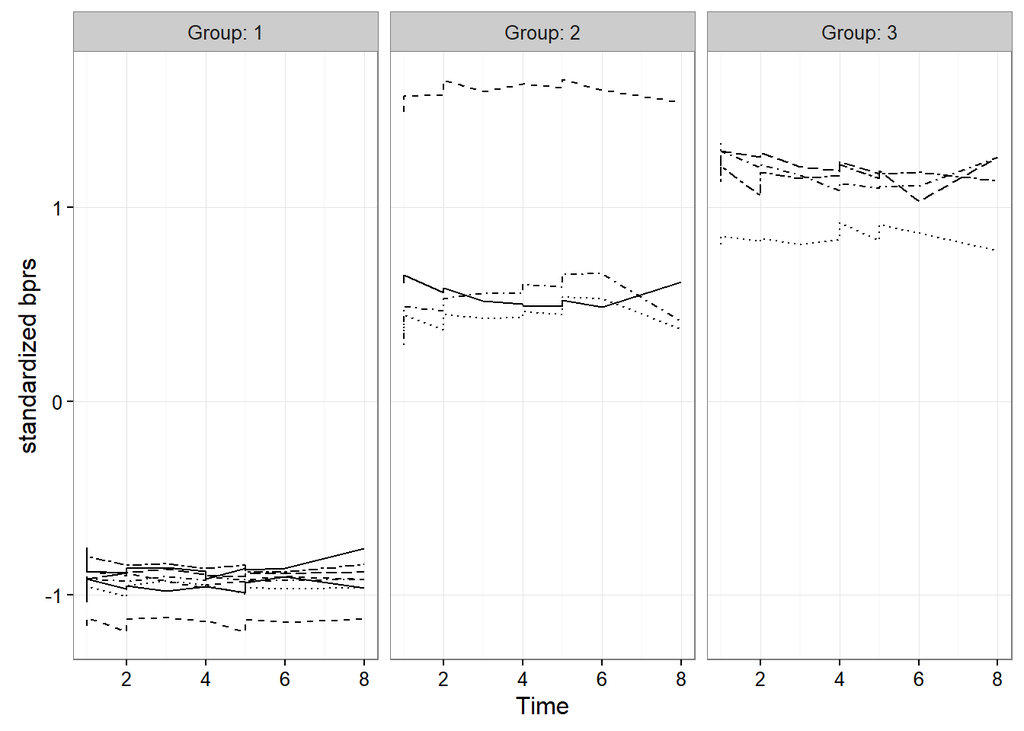

### Mean weight profiles for the diet groups

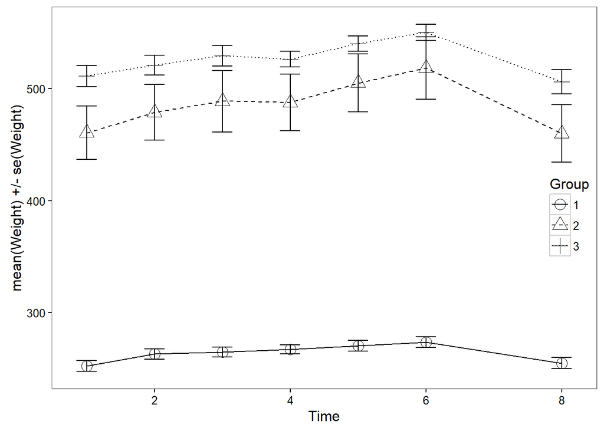

Here we can see the profiles of mean weights in each groups. The mean profiles look quite the same as the individual profiles, and we can see that group 2 means have high standard errors because one rat had markedly higher weight than others in that group.

### Boxplots

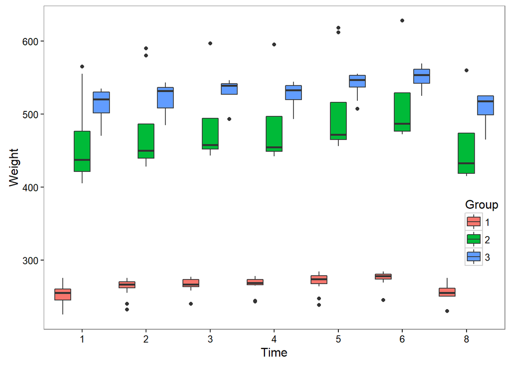

I’m not sure if boxplots are the best method for visualizing data that we have here, because we only have a few subjects per group per timepoint. I find the boxplots a bit misleading, as the quantiles don’t really tell much with such small N’s. But overall we can see the same story as from the previous mean plots.

### Boxplots of mean summary measures

```
## Observations: 16
## Variables: 3
## $ Group (fctr) 1, 1, 1, 1, 1, 1, 1, 1, 2, 2, 2, 2, 3, 3, 3, 3
## $ ID    (fctr) 1, 2, 3, 4, 5, 6, 7, 8, 9, 10, 11, 12, 13, 14, 15, 16
## $ mean  (dbl) 264.1111, 239.8889, 263.0000, 268.5556, 272.6667, 276.88...
```

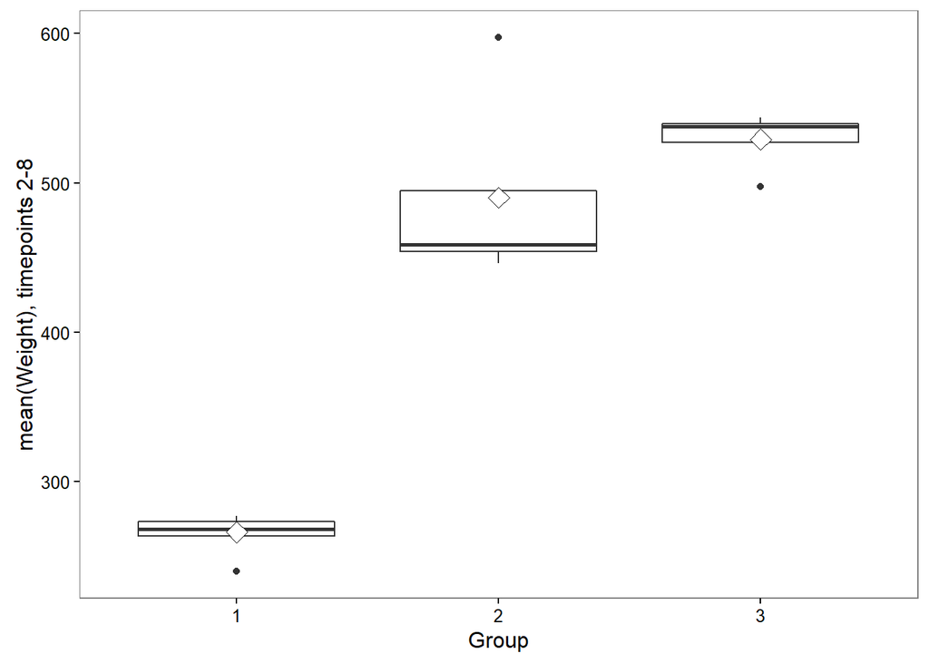

All groups seem to have one outlier. We could remove the outliers, but the individual growth profiles showed that their profiles are actually similar to other individuals in their groups. Also, we are really not interested in the weight difference between the means of the groups accross time, but between the mean weight change of the groups. COnsidering that the groups were really different in the beginning, we don’t get much information from these kind of plots. Let’s however remove the most obvious outlier from group 2 and check what the boxplot looks like.

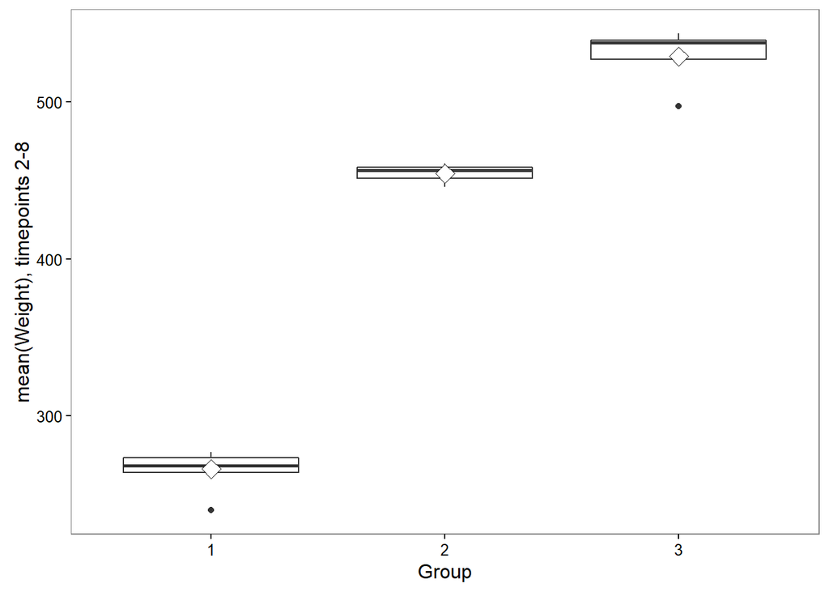

Next in the MABS they performed t-tests for BPRS data. However, unlike in the BPRS data, here we have 3 groups instead of 2. Hence we cannot perform t-tests with the RATS data. We could do t-tests between the different groups and then adjusts the p-values, but we are really not interested in finding out whether there is a difference in the means of the groups, as there was already a difference in the beginning, and this difference doesn’t really tell anything about the effect of the different diets.

### Analysis of covariance

```
##
## Call:
## lm(formula = mean ~ baseline + Group, data = RATS8S2)
##
## Residuals:
##     Min      1Q  Median      3Q     Max
## -25.493  -4.188   2.205   7.448  15.727
##
## Coefficients:
##             Estimate Std. Error t value Pr(>|t|)
## (Intercept) 33.69364   22.81191   1.477   0.1654
## baseline     0.92774    0.08938  10.379 2.39e-07 ***
## Group2      35.40015   19.62787   1.804   0.0964 .
## Group3      23.34671   24.24745   0.963   0.3546
## ---
## Signif. codes:  0 '***' 0.001 '**' 0.01 '*' 0.05 '.' 0.1 ' ' 1
##
## Residual standard error: 12.18 on 12 degrees of freedom
## Multiple R-squared:  0.9931, Adjusted R-squared:  0.9914
## F-statistic: 575.2 on 3 and 12 DF,  p-value: 3.174e-13
```

```
## Analysis of Variance Table
##
## Response: mean
##           Df Sum Sq Mean Sq   F value   Pr(>F)
## baseline   1 254912  254912 1719.1122 2.51e-14 ***
## Group      2    944     472    3.1821  0.07785 .
## Residuals 12   1779     148
## ---
## Signif. codes:  0 '***' 0.001 '**' 0.01 '*' 0.05 '.' 0.1 ' ' 1
```

From the analysis of covariance we can see that there is a diffence in the means of the different groups, but it’s mainly due the difference in the baseline, so we cannot make interpretations about the effect of the diet.

We don’t have any missing values, so we don’t have to deal with them :).

*As a summary, I think that the analysis approach that we took here is not very well suited to our data, because the weights of the individuals are not balanced between the groups before starting the diet. From the first plots we can see that the weight profiles seem quite similar across diets, but we cannot say if there is a difference between them or not. A different approach should be taken to find that out. This was interesting exercise in that sense though, it is good to aknowledge that the approach needs to suit the datatype that were are using.*

## Analysis of BPRS data set

BPRS data set consist of weekly measures of brief psychiatric rating scale (BPRS) from 40 male subjects. The data set is from Davis (2002). The BPRS assesses the level of 18 schizophrenia symptom constructs (Vehkalahti and Everitt, 2019).

Let’s start by downloading the data, factorizing the variables and creating a new factorized variable, ind_subject, which consist of the subject ID and treatment (subject.treatment). We need to do this to separate subjects with the same number in treatment 1 and 2.

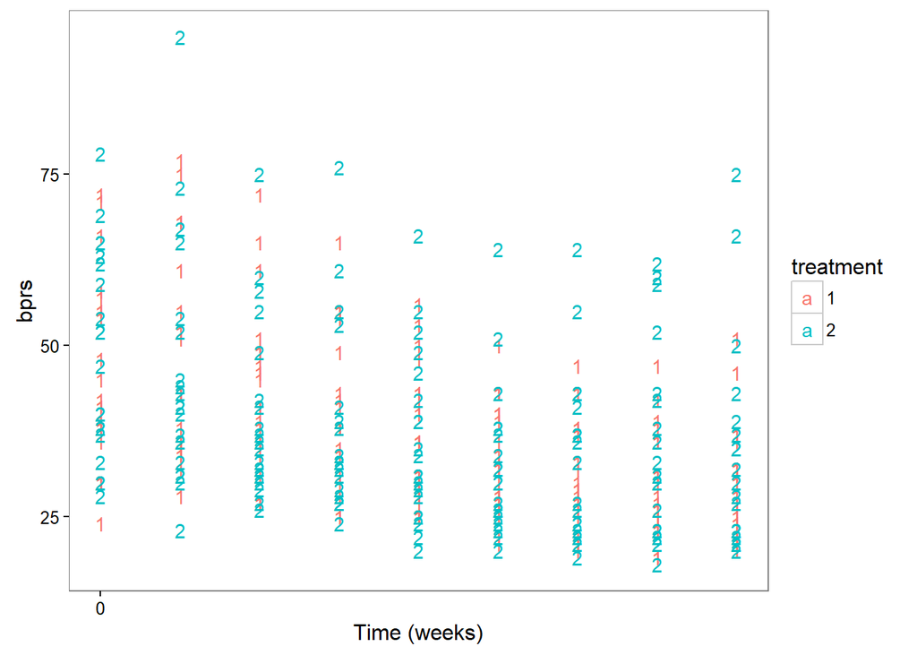

From this overview we can see that there is not much difference between treatment groups. Overall the bprs scores seem to go down slightly towards the end in the sense that there are more patients with lower scores. The patients with high baseline scores in group 1 seem to lose some of the symptoms towards the end, where as in group there are also patients with high scores during the last weeks, but it’s hard to say if these differences are statistically significant or just random.

### individual bprs profiles

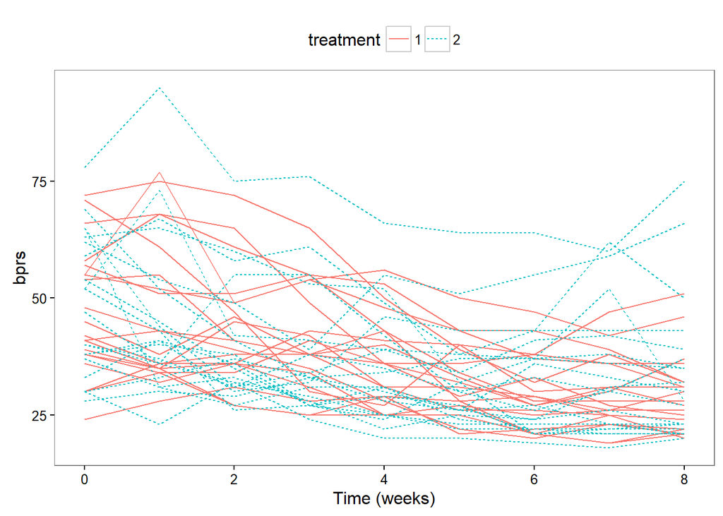

Here we can see the same trend as in the previous plot: In most cases the scores seem to slightly go down. This happens especially in the group 1, where as in group 2 there are some cases in where the scores start rising towards the end.

### Fitting a Linear Regression Model to BPRS data

```
##
## Call:
## lm(formula = bprs ~ week + treatment, data = BPRS)
##
## Residuals:
##     Min      1Q  Median      3Q     Max
## -22.454  -8.965  -3.196   7.002  50.244
##
## Coefficients:
##             Estimate Std. Error t value Pr(>|t|)
## (Intercept)  46.4539     1.3670  33.982   <2e-16 ***
## week         -2.2704     0.2524  -8.995   <2e-16 ***
## treatment2    0.5722     1.3034   0.439    0.661
## ---
## Signif. codes:  0 '***' 0.001 '**' 0.01 '*' 0.05 '.' 0.1 ' ' 1
##
## Residual standard error: 12.37 on 357 degrees of freedom
## Multiple R-squared:  0.1851, Adjusted R-squared:  0.1806
## F-statistic: 40.55 on 2 and 357 DF,  p-value: < 2.2e-16
```

In this model we have bprs score as the response variable and weeks and treatment as explanatory variables. It looks like treatment doesn’t have a significant effect on the bprs score, but time has a negative effect on the scores (scores drop as time passes, which is positive of course in this case).

Let’s skip the scatterplot, we already know that the bprs scores are not independent of each other over time.

```
## Linear mixed model fit by maximum likelihood  ['lmerMod']
## Formula: bprs ~ week + treatment + (1 | ind_subject)
##    Data: BPRS
##
##      AIC      BIC   logLik deviance df.resid
##   2582.9   2602.3  -1286.5   2572.9      355
##
## Scaled residuals:
##      Min       1Q   Median       3Q      Max
## -2.27506 -0.59909 -0.06104  0.44226  3.15835
##
## Random effects:
##  Groups      Name        Variance Std.Dev.
##  ind_subject (Intercept) 97.39    9.869
##  Residual                54.23    7.364
## Number of obs: 360, groups:  ind_subject, 40
##
## Fixed effects:
##             Estimate Std. Error t value
## (Intercept)  46.4539     2.3521  19.750
## week         -2.2704     0.1503 -15.104
## treatment2    0.5722     3.2159   0.178
##
## Correlation of Fixed Effects:
##            (Intr) week
## week       -0.256
## treatment2 -0.684  0.000
```

We can see that the standard error of time decreased. This is because the previous model ignored the dependencies between within subject measurements, increasing the standard error of within-subject covariates. In cotrast, the new model gives treatment a larger standard error.

That’s all for today, no time to do rest of the analysis..